# Week 12, Lesson 22: Simulation

AG Schissler, modified from R. Tibshirani

Monday November 14, 2018

## I. Opening

### Start-of-class work

1. Log in the your workstation.
2. Open the RStudio application on your machine.
3. Open lesson22_simulation.Rmd from website so that you can work along the lecture.

### This week’s agenda

- This week begins the third and final unit of the course: Statistical Inference through Computing.
- You reviewed probability in DataCamp last week

## II. DataCamp Foundations of Probability

- Probability is the main mathematical tool for understanding randomness and predictable variation.
- We won’t focus on analytic manipulations, but you need to have a good familiarity with the concepts to complete the assignments and final exam.
- How did it go? Any questions or other things to discuss?

## III. Introduction to Simulation

- We’re been simulating from almost the first (using `rbinom`).
- This lecture goes deeper and uses simulation to gather statistical evidence and test hypotheses.
- R gives us unique access to great simulation tools (unique compared to other languages). Why simulate? Welcome to the 21st century! Two reasons:
  1. Often, simulations can be easier than hand calculations
  2. Often, simulations can be made more realistic than hand calculations.

## IV. Simulation 101

### Sampling from a given vector

To sample from a given vector, use `sample()`

```r
sample(x=letters, size=10) # Without replacement, the default
```

```
##  [1] "t" "q" "m" "y" "n" "s" "v" "b" "u" "k"
```

```r
sample(x=c(0,1), size=10, replace=TRUE) # With replacement
```

```
##  [1] 0 0 0 1 1 0 1 1 1 0
```

```r
sample(x=10) # Arguments set as x=1:10, size=10, replace=FALSE
```

```
##  [1]  5  3  1  7  6  8 10  4  9  2
```

### Random number generation

To sample from a normal distribution, we have the utility functions:

- `rnorm()`: generate normal random variables
- `pnorm()`: normal distribution function, $\Phi(x)=P(Z \leq x)$
- `dnorm()`: normal density function, $\phi(x)= \Phi'(x)$
- `qnorm()`: normal quantile function, $q(y)=\Phi^{-1}(y)$, i.e., $\Phi(q(y))=y$

Replace “norm” with the name of another distribution, all the same functions apply. E.g., “t”, “exp”, “gamma”, “chisq”, “binom”, “pois”, etc.

### Random number examples

Standard normal random variables (mean 0 and variance 1)

```r
n = 1000
z = rnorm(n, mean=0, sd=1) # These are the defaults for mean, sd
mean(z)  # Check: sample mean is approximately 0
```

```
## [1] -0.002852723
```

```r
var(z)   # Check: sample variance is approximately 1
```

```
## [1] 0.9954884
```

### Estimated distribution function

To compute empirical cumulative distribution function (ECDF)—the standard estimator of the cumulative distribution function—use `ecdf()`

```r
x = seq(-3,3,length=100)
ecdf.fun = ecdf(z) # Create the ECDF
class(ecdf.fun) # It's a function!
```

```
## [1] "ecdf"     "stepfun"  "function"
```

```r
ecdf.fun(0)
```

```
## [1] 0.504
```

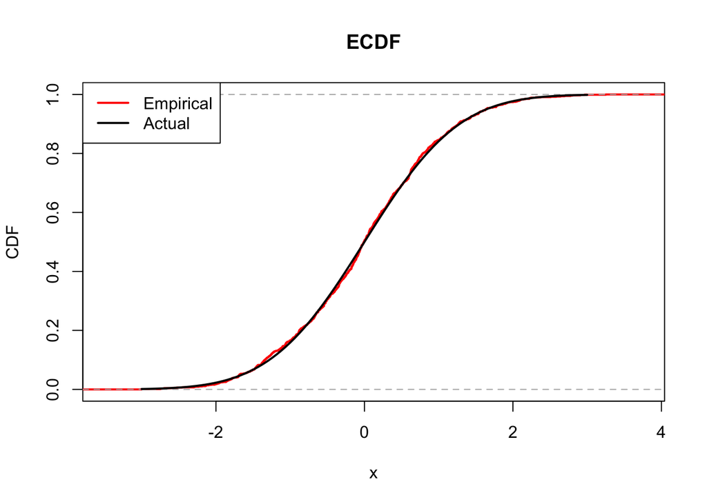

```r
# We can plot it
plot(ecdf.fun, lwd=2, col="red", ylab="CDF", main="ECDF")
lines(x, pnorm(x), lwd=2)
legend("topleft", legend=c("Empirical", "Actual"), lwd=2,
       col=c("red","black"))
```

### Interlude: Kolmogorov-Smirnov test

One of the most celebrated tests in statistics is due to Kolmogorov in 1933. The *Kolmogorov-Smirnoff (KS) statistic* is:
$$\sqrt{\frac{n}{2}} \sup_{x} |F_n(x)-G_n(x)|$$
Here $F_n$ is the ECDF of $X_1,\ldots,X_n \sim F$, and $G_n$ is the ECDF of $Y_1,\ldots,Y_n \sim G$. Under $F=G$ (two distributions are the same), as $n \to \infty$, the KS statistic approaches the supremum of a Brownian bridge:
$$\sup_{t \in [0,1]} |B(t)|$$

Here $B$ is a Gaussian process with $B(0)=B(1)=0$, mean $\mathbb{E}(B(t))=0$ for all $t$, and covariance function $\mathrm{Cov}(B(s), B(t)) = s(1-t)$

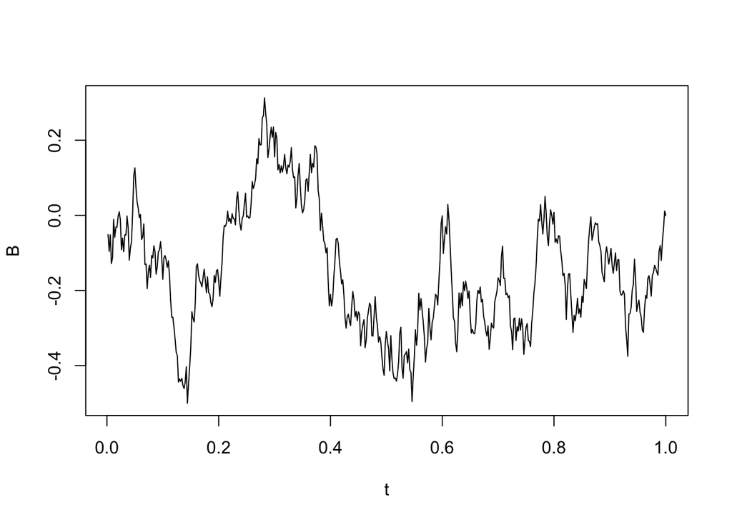

```r
n = 500
t = 1:n/n
Sig = t %o% (1-t)
Sig = pmin(Sig, t(Sig))
eig = eigen(Sig)
Sig_half = eig$vec %*% diag(sqrt(eig$val)) %*% t(eig$vec)
B = Sig_half %*% rnorm(n)
plot(t, B, type="l")
```

Two remarkable facts about the KS test:

1. It is *distribution-free*, meaning that the null distribution doesn’t depend on $F,G$!
2. We can actually compute the null distribution and use this test, e.g., via `ks.test()`:

```r
ks.test(rnorm(n), rt(n, df=1)) # Normal versus t1
```

```
##
##  Two-sample Kolmogorov-Smirnov test
##
## data:  rnorm(n) and rt(n, df = 1)
## D = 0.158, p-value = 7.589e-06
## alternative hypothesis: two-sided
```

```r
ks.test(rnorm(n), rt(n, df=10)) # Normal versus t10
```

```
##
##  Two-sample Kolmogorov-Smirnov test
##
## data:  rnorm(n) and rt(n, df = 10)
## D = 0.044, p-value = 0.7184
## alternative hypothesis: two-sided
```

### Estimated density function

To compute histogram—a basic estimator of the density based on binning—use `hist()`

```r
hist.obj = hist(z, breaks=30, plot=FALSE)
class(hist.obj) # It's a list
```

```
## [1] "histogram"
```

```r
hist.obj$breaks # These are the break points that were used
```

```
##  [1] -3.2 -3.0 -2.8 -2.6 -2.4 -2.2 -2.0 -1.8 -1.6 -1.4 -1.2 -1.0 -0.8 -0.6
## [15] -0.4 -0.2  0.0  0.2  0.4  0.6  0.8  1.0  1.2  1.4  1.6  1.8  2.0  2.2
## [29]  2.4  2.6  2.8  3.0  3.2  3.4
```

```r
hist.obj$density # These are the estimated probabilities
```

```
##  [1] 0.005 0.000 0.015 0.015 0.015 0.040 0.080 0.105 0.140 0.230 0.185
## [12] 0.245 0.280 0.310 0.360 0.495 0.420 0.385 0.290 0.395 0.220 0.210
## [23] 0.140 0.145 0.090 0.055 0.055 0.030 0.010 0.015 0.015 0.000 0.005
```

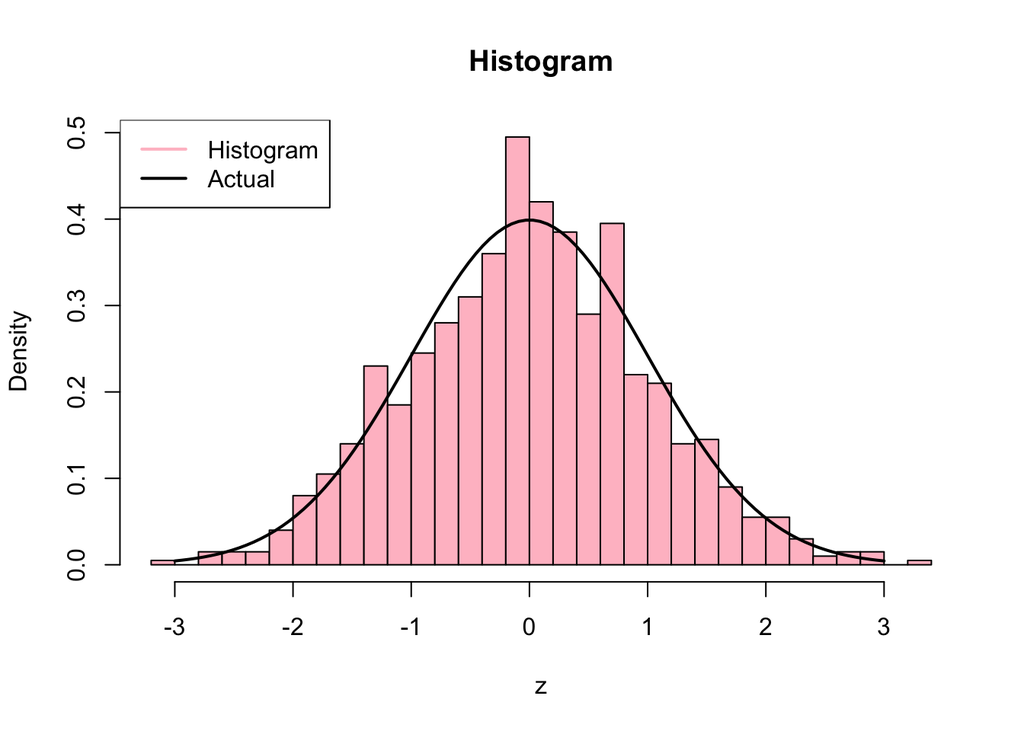

```r
# We can plot it
plot(hist.obj, col="pink", freq=FALSE, main="Histogram")
lines(x, dnorm(x), lwd=2)
legend("topleft", legend=c("Histogram", "Actual"), lwd=2,
       col=c("pink","black"))
```

## V. Pseudorandomness and seeds

#### Same function call, different results

Not surprisingly, we get different draws each time we call `rnorm()`

```r
mean(rnorm(n))
```

```
## [1] 0.0469547
```

```r
mean(rnorm(n))
```

```
## [1] 0.0133331
```

```r
mean(rnorm(n))
```

```
## [1] -0.008195039
```

```r
mean(rnorm(n))
```

```
## [1] 0.02553705
```

#### Is it really random?

Random numbers generated in R (in any language) are not “truly” random; they are what we call **pseudorandom**

- These are numbers generated by computer algorithms that very closely mimick “truly” random numbers
- The study of such algorithms is an interesting research area in its own right!
- The default algorithm in R (and in nearly all software languages) is called the “Mersenne Twister”
- Type `?Random` in your R console to read more about this (and to read how to change the algorithm used for pseudorandom number generation, which you should never really have to do, by the way)

#### Setting the random seed

All pseudorandom number generators depend on what is called a **seed** value

- This puts the random number generator in a well-defined “state”, so that the numbers it generates, from then on, will be reproducible
- The seed is just an integer, and can be set with `set.seed()`
- The reason we set it: so that when someone else runs our simulation code, they can see the same—albeit, still random—results that we do
- This can be tricky using RStudio and RMarkdown. Don’t sweat it until you knit the final document

#### Seed examples

```r
# Getting the same 5 random normals over and over
set.seed(0); rnorm(5)
```

```
## [1]  1.2629543 -0.3262334  1.3297993  1.2724293  0.4146414
```

```r
set.seed(0); rnorm(5)
```

```
## [1]  1.2629543 -0.3262334  1.3297993  1.2724293  0.4146414
```

```r
set.seed(0); rnorm(5)
```

```
## [1]  1.2629543 -0.3262334  1.3297993  1.2724293  0.4146414
```

```r
# Different seeds, different numbers
set.seed(1); rnorm(5)
```

```
## [1] -0.6264538  0.1836433 -0.8356286  1.5952808  0.3295078
```

```r
set.seed(2); rnorm(5)
```

```
## [1] -0.89691455  0.18484918  1.58784533 -1.13037567 -0.08025176
```

```r
set.seed(3); rnorm(5)
```

```
## [1] -0.9619334 -0.2925257  0.2587882 -1.1521319  0.1957828
```

```r
# Each time the seed is set, the same sequence follows (indefinitely)
set.seed(0); rnorm(3); rnorm(2); rnorm(1)
```

```
## [1]  1.2629543 -0.3262334  1.3297993
```

```
## [1] 1.2724293 0.4146414
```

```
## [1] -1.53995
```

```r
set.seed(0); rnorm(3); rnorm(2); rnorm(1)
```

```
## [1]  1.2629543 -0.3262334  1.3297993
```

```
## [1] 1.2724293 0.4146414
```

```
## [1] -1.53995
```

```r
set.seed(0); rnorm(3); rnorm(2); rnorm(1)
```

```
## [1]  1.2629543 -0.3262334  1.3297993
```

```
## [1] 1.2724293 0.4146414
```

```
## [1] -1.53995
```

## VI. Iteration and simulation

### Drug effect model

- Let’s start with a motivating example: suppose we had a model for the way a drug affected certain patients
- All patients will undergo chemotherapy. We believe those who aren’t given the drug experience a reduction in tumor size of percentage
  $$X_{\mathrm{no\,drug}} \sim 100 \cdot \mathrm{Exp}(\mathrm{mean}=R),
  \;\;\; R \sim \mathrm{Unif}(0,1)$$
- And those who were given the drug experience a reduction in tumor size of percentage
  $$X_{\mathrm{drug}} \sim 100 \cdot \mathrm{Exp}(\mathrm{mean}=2)$$
  (Here $\mathrm{Exp}$ denotes the exponential distribution, and $\mathrm{Unif}$ the uniform distribution)

### What would you do?

What would you do if you had such a model, and your scientist collaborators asked you: *how many patients would we need to have in each group (drug, no drug), in order to reliably see that the average reduction in tumor size is large?*

- Answer used to be: get out your pen and paper, make some approximations
- Answer is now: simulate from the model, no approximations required!

### So, let’s simulate!

```r
# Simulate, supposing 60 subjects in each group
set.seed(0)
n = 60
mu_drug = 2
mu_nodrug = runif(n, min=0, max=1)
x_drug = 100*rexp(n, rate=1/mu_drug)
x_nodrug = 100*rexp(n, rate=1/mu_nodrug)
```

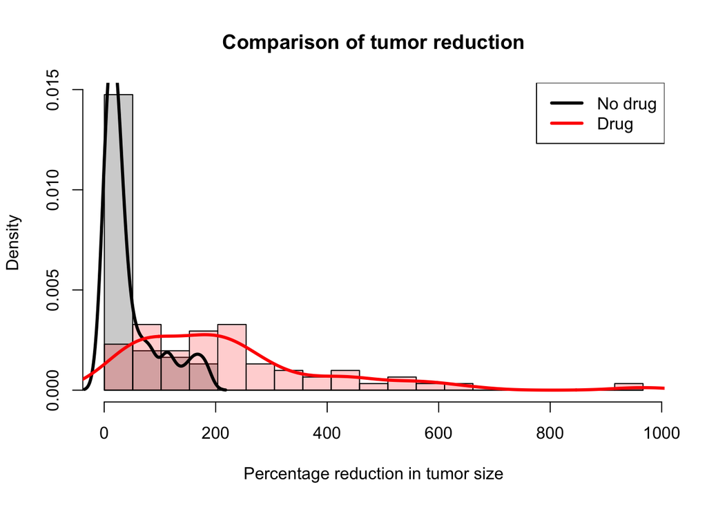

```r
# Find the range of all the measurements together, and define breaks
x_range = range(c(x_nodrug,x_drug))
breaks = seq(min(x_range),max(x_range),length=20)

# Produce hist of the non drug measurements, then drug measurements on top
hist(x_nodrug, breaks=breaks, probability=TRUE, xlim=x_range,
     col="lightgray", xlab="Percentage reduction in tumor size",
     main="Comparison of tumor reduction")

# Plot a histogram of the drug measurements, on top
hist(x_drug, breaks=breaks, probability=TRUE, col=rgb(1,0,0,0.2), add=TRUE)

# Draw estimated densities on top, for each dist
lines(density(x_nodrug), lwd=3, col=1)
lines(density(x_drug), lwd=3, col=2)
legend("topright", legend=c("No drug","Drug"), lty=1, lwd=3, col=1:2)
```

### Repetition and reproducibility

- One single simulation is not always trustworthy (depends on the situation, of course)
- In general, simulations should be repeated and aggregate results reported—requires iteration!
- To make random number draws reproducible, we must set the seed with `set.seed()`
- More than this, to make simulation results reproducible, we need to follow **good programming practices**
- Gold standard: any time you show a simulation result (a figure, a table, etc.), you have code that can be run (by anyone) to produce exactly the same result

### Iteration and simulation (and functions): good friends

- Writing a **function** to complete a single run of your simulation is often very helpful
- This allows the simulation itself to be intricate (e.g., intricate steps, several simulation parameters), but makes running the simulation simple
- Then you can use **iteration** to run your simulation over and over again
- Good design practice: write another function for this last part (running your simulation many times)

### Code sketch

Consider the code below for a generic simulation. Think about how you would frame this for the drug effect example, which you’ll revisit in lab

```
# Function to do one simulation run
one_sim = function(param1, param2=value2, param3=value3) {
  # Possibly intricate simulation code goes here
}

# Function to do repeated simulation runs
rep_sim = function(nreps, param1, param2=value2, param3=value3, seed=NULL) {
  # Set the seed, if we need to
  if(!is.null(seed)) set.seed(seed)

  # Run the simulation over and over
  sim_objs = vector(length=nreps, mode="list")
  ## for loop here,
  ## but other iteration techniques may be more efficient (e.g. sapply)
  for (r in 1:nreps) {
    sim_objs[r] = one_sim(param1, param2, param3)
  }

  # Aggregate the results somehow, and then return something
}
```

### Saving results

Sometimes simulations take a long time to run, and we want to save intermediate or final output, for quick reference later

There two different ways of saving things from R (there are more than two, but here are two useful ones):

- `saveRDS()`: allows us to save single R objects (like a vector, matrix, list, etc.), in (say) .rds format. E.g.,

  ```r
  saveRDS(my.mat, file="my.matrix.rds")
  ```

- `save()`: allows us to save any number of R objects in (say) .rdata format. E.g.,

  ```r
  save(mat.x, mat.y, list.z, file="my.objects.rdata")
  ```

Note: there is a big difference between how these two treat variable names

### Loading results

Corresponding to the two different ways of saving, we have two ways of loading things into R:

- `readRDS()`: allows us to load an object that has been saved by `savedRDS()`, and **assign a new variable name**. E.g.,

  ```r
  my.new.mat = readRDS("my.matrix.rds")
  ```

- `load()`: allows us to load all objects that have been saved through `save()`, **according to their original variables names**. E.g.,

  ```r
  load("my.objects.rdata")
  ```

## VII. Summary

- 3 `R` functions
- 2 new statistical facts/ideas
- 1 question